# Data Wrangling (continued) and ANOVA

STAT 230

4/4/2017

## Tidy Data

As we transition from data acquisition/cleaning to data analysis, we’ll really want to make sure that our dataset is in a format that is ready for analysis. “Tidy data” (coined by Hadley Wickham, author of dplyr, tidyr, ggplot2 packages) is described by two features:

- each variable is stored in its own column
- each observation is stored in its own row

Sometimes it’s not so clear what each “variable” or unit of “observation” is meant to be… other times, it’s very clear that your data will need fixing up before standard analyses may be applied.

## Financial Data

```r
fin <- read.csv("stock_dat.csv", as.is=T)
head(fin)
```

```
##   year month day    FB     GOOG  MSFT
## 1 2013     1   2 28.00 723.2512 27.62
## 2 2013     1   3 27.77 723.6713 27.25
## 3 2013     1   4 28.76 737.9713 26.74
## 4 2013     1   7 29.42 734.7513 26.69
## 5 2013     1   8 29.06 733.3012 26.55
## 6 2013     1   9 30.59 738.1212 26.70
```

How can we plot these stock prices?

We’ll start by creating a date column:

```r
fin <- fin %>% unite(date, year, month, day, sep="-")
head(fin)
```

```
##       date    FB     GOOG  MSFT
## 1 2013-1-2 28.00 723.2512 27.62
## 2 2013-1-3 27.77 723.6713 27.25
## 3 2013-1-4 28.76 737.9713 26.74
## 4 2013-1-7 29.42 734.7513 26.69
## 5 2013-1-8 29.06 733.3012 26.55
## 6 2013-1-9 30.59 738.1212 26.70
```

(To undo this:)

```r
fin %>% separate(date, c("year", "month", "day"), sep="-") %>% head()
```

```
##   year month day    FB     GOOG  MSFT
## 1 2013     1   2 28.00 723.2512 27.62
## 2 2013     1   3 27.77 723.6713 27.25
## 3 2013     1   4 28.76 737.9713 26.74
## 4 2013     1   7 29.42 734.7513 26.69
## 5 2013     1   8 29.06 733.3012 26.55
## 6 2013     1   9 30.59 738.1212 26.70
```

Convert this `date` variable into a date:

```r
fin <- fin %>% mutate(date = ymd(date))
head(fin)
```

```
##         date    FB     GOOG  MSFT
## 1 2013-01-02 28.00 723.2512 27.62
## 2 2013-01-03 27.77 723.6713 27.25
## 3 2013-01-04 28.76 737.9713 26.74
## 4 2013-01-07 29.42 734.7513 26.69
## 5 2013-01-08 29.06 733.3012 26.55
## 6 2013-01-09 30.59 738.1212 26.70
```

Now, let’s plot the stock prices over time:

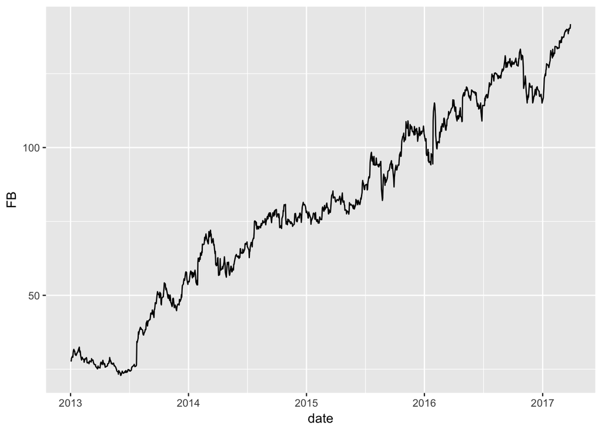

```r
ggplot(fin, aes(x=date, y = FB)) + geom_line()
```

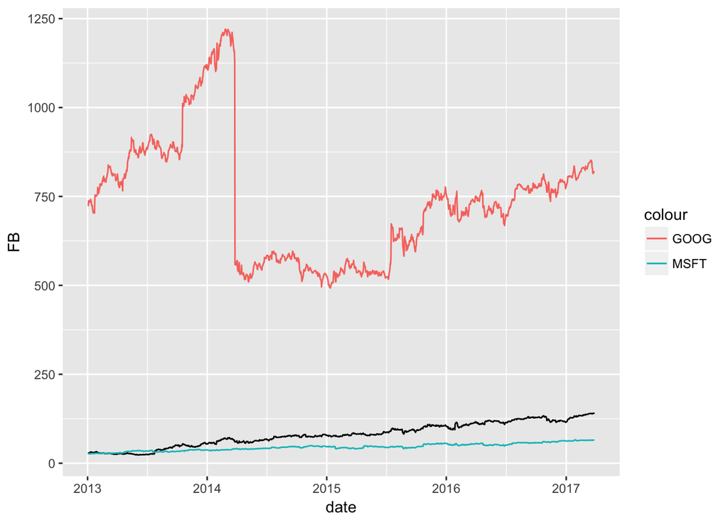

```r
ggplot(fin, aes(x=date, y = FB)) + geom_line() +
  geom_line(aes(y=GOOG, col="GOOG")) +
  geom_line(aes(y=MSFT, col="MSFT"))
```

Let’s reformat this dataset so that we have a column for date, a column for company, and a column for price:

```r
fin2 <- fin %>% gather(company, price, FB:MSFT)
head(fin2)
```

```
##         date company price
## 1 2013-01-02      FB 28.00
## 2 2013-01-03      FB 27.77
## 3 2013-01-04      FB 28.76
## 4 2013-01-07      FB 29.42
## 5 2013-01-08      FB 29.06
## 6 2013-01-09      FB 30.59
```

```r
unique(fin2$company)
```

```
## [1] "FB"   "GOOG" "MSFT"
```

Using this dataset, we can now make the plot a lot easier!

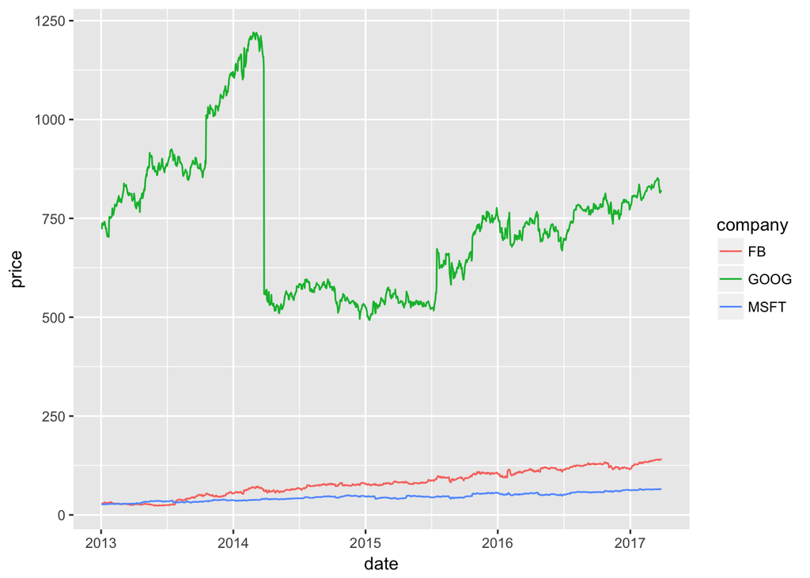

```r
ggplot(fin2, aes(x=date, y=price, col=company)) + geom_line()
```

## Back to NYC Flights

Now we’ll use `tidyr` to examine the overall trend in arrival/departure delays over the course of each day.

Let’s remove the NA’s again, as we did last class:

```r
flights <- flights %>% filter(!is.na(arr_delay) & !is.na(dep_delay))
```

Let’s use gather:

```r
df <- flights %>% gather(delay_type, delay_val,
                         c(dep_delay, arr_delay))
df %>% select(delay_type:delay_val)
```

```
## # A tibble: 654,692 × 2
##    delay_type delay_val
##         <chr>     <dbl>
## 1   dep_delay         2
## 2   dep_delay         4
## 3   dep_delay         2
## 4   dep_delay        -1
## 5   dep_delay        -6
## 6   dep_delay        -4
## 7   dep_delay        -5
## 8   dep_delay        -3
## 9   dep_delay        -3
## 10  dep_delay        -2
## # ... with 654,682 more rows
```

Now, compute some summary statistics regarding departure and arrival delays:

```r
df <- df %>% mutate(delay_type = ifelse(delay_type == "dep_delay", "Departure", "Arrival")) %>%
  group_by(hour, delay_type) %>%
  summarize(mean = mean(delay_val),
            se = sqrt(var(delay_val)/length(delay_val)),
            obs = length(delay_val))
head(df)
```

```
## Source: local data frame [6 x 5]
## Groups: hour [3]
##
##    hour delay_type       mean        se   obs
##   <dbl>      <chr>      <dbl>     <dbl> <int>
## 1     5    Arrival -4.7969072 0.5048938  1940
## 2     5  Departure  0.6886598 0.3608131  1940
## 3     6    Arrival -3.3844854 0.1771532 25447
## 4     6  Departure  1.5950014 0.1462943 25447
## 5     7    Arrival -5.3044716 0.1946501 22475
## 6     7  Departure  1.9103448 0.1562666 22475
```

To plot:

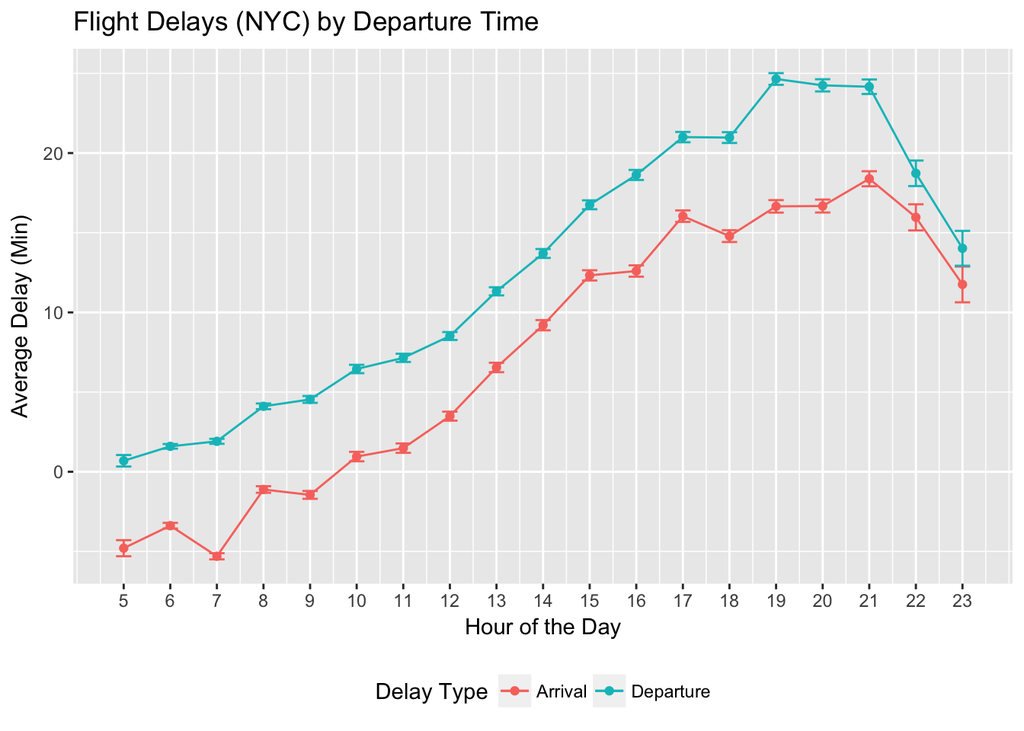

```r
ggplot(df, aes(x=hour, y=mean, col=delay_type)) + geom_line() + geom_point() +
  geom_errorbar(aes(min=mean-se, max = mean + se), width=0.33) +
  scale_x_continuous(breaks=5:23) +
  labs(x="Hour of the Day", y="Average Delay (Min)", title = "Flight Delays (NYC) by Departure Time") +
  theme(legend.position = "bottom") +
  scale_color_discrete(name = "Delay Type")
```

## Runners dataset

This dataset includes data from runners who averaged at least 15 miles per week and a control group described as generally sedentary. Both men and women were included in the study. Individuals in the study were asked to run six minutes on a treadmill and their heart rates were subsequently recorded.

```r
y <- read.csv("heartrates.csv", as.is=TRUE)
head(y)
```

```
##     group gender hr_1 hr_2 hr_3 hr_4 hr_5 hr_6 hr_7 hr_8 hr_9 hr_10 hr_11
## 1 Control Female  159  183  140  140  125  155  148  132  158   136   154
## 2 Control   Male  127   99  157  102   97  122  128  136  142   127   127
## 3 Runners Female  119   84   89  119  127  111  115  109  111   120   105
## 4 Runners   Male  100  120   93  107  138   96  107  119   99   102    87
##   hr_12 hr_13 hr_14 hr_15 hr_16 hr_17 hr_18 hr_19 hr_20 hr_21 hr_22 hr_23
## 1   169   147   183   167   151   166   134   131   164   164   169   127
## 2   157   125   113   131   114   143   133   143   128   137   143   134
## 3   104    94   126   113   141   116   104    82   164   119   110   109
## 4    88    80   120   104   110   127   112    96    87    94    81   116
##   hr_24 hr_25 hr_26 hr_27 hr_28 hr_29 hr_30 hr_31 hr_32 hr_33 hr_34 hr_35
## 1   126   141   163   152   150   151   162   148   162   136   134   133
## 2   107   137   153    95   144   134   129   131   152   109    95    96
## 3   106   125   106   108   122   145   115   110    92   114   121   123
## 4   102   102    98    97   103    97   101    86    92   119   121   103
```

[output cut: 80 more lines]

```r
names(y)
```

```
##   [1] "group"  "gender" "hr_1"   "hr_2"   "hr_3"   "hr_4"   "hr_5"
##   [8] "hr_6"   "hr_7"   "hr_8"   "hr_9"   "hr_10"  "hr_11"  "hr_12"
##  [15] "hr_13"  "hr_14"  "hr_15"  "hr_16"  "hr_17"  "hr_18"  "hr_19"
##  [22] "hr_20"  "hr_21"  "hr_22"  "hr_23"  "hr_24"  "hr_25"  "hr_26"
##  [29] "hr_27"  "hr_28"  "hr_29"  "hr_30"  "hr_31"  "hr_32"  "hr_33"
##  [36] "hr_34"  "hr_35"  "hr_36"  "hr_37"  "hr_38"  "hr_39"  "hr_40"
##  [43] "hr_41"  "hr_42"  "hr_43"  "hr_44"  "hr_45"  "hr_46"  "hr_47"
##  [50] "hr_48"  "hr_49"  "hr_50"  "hr_51"  "hr_52"  "hr_53"  "hr_54"
##  [57] "hr_55"  "hr_56"  "hr_57"  "hr_58"  "hr_59"  "hr_60"  "hr_61"
##  [64] "hr_62"  "hr_63"  "hr_64"  "hr_65"  "hr_66"  "hr_67"  "hr_68"
##  [71] "hr_69"  "hr_70"  "hr_71"  "hr_72"  "hr_73"  "hr_74"  "hr_75"
##  [78] "hr_76"  "hr_77"  "hr_78"  "hr_79"  "hr_80"  "hr_81"  "hr_82"
##  [85] "hr_83"  "hr_84"  "hr_85"  "hr_86"  "hr_87"  "hr_88"  "hr_89"
##  [92] "hr_90"  "hr_91"  "hr_92"  "hr_93"  "hr_94"  "hr_95"  "hr_96"
##  [99] "hr_97"  "hr_98"  "hr_99"  "hr_100" "hr_101" "hr_102" "hr_103"
## [106] "hr_104" "hr_105" "hr_106" "hr_107" "hr_108" "hr_109" "hr_110"
## [113] "hr_111" "hr_112" "hr_113" "hr_114" "hr_115" "hr_116" "hr_117"
## [120] "hr_118" "hr_119" "hr_120" "hr_121" "hr_122" "hr_123" "hr_124"
## [127] "hr_125" "hr_126" "hr_127" "hr_128" "hr_129" "hr_130" "hr_131"
## [134] "hr_132" "hr_133" "hr_134" "hr_135" "hr_136" "hr_137" "hr_138"
## [141] "hr_139" "hr_140" "hr_141" "hr_142" "hr_143" "hr_144" "hr_145"
## [148] "hr_146" "hr_147" "hr_148" "hr_149" "hr_150" "hr_151" "hr_152"
## [155] "hr_153" "hr_154" "hr_155" "hr_156" "hr_157" "hr_158" "hr_159"
## [162] "hr_160" "hr_161" "hr_162" "hr_163" "hr_164" "hr_165" "hr_166"
## [169] "hr_167" "hr_168" "hr_169" "hr_170" "hr_171" "hr_172" "hr_173"
## [176] "hr_174" "hr_175" "hr_176" "hr_177" "hr_178" "hr_179" "hr_180"
## [183] "hr_181" "hr_182" "hr_183" "hr_184" "hr_185" "hr_186" "hr_187"
## [190] "hr_188" "hr_189" "hr_190" "hr_191" "hr_192" "hr_193" "hr_194"
## [197] "hr_195" "hr_196" "hr_197" "hr_198" "hr_199" "hr_200"
```

```r
head(y[,1:4])
```

```
##     group gender hr_1 hr_2
## 1 Control Female  159  183
## 2 Control   Male  127   99
## 3 Runners Female  119   84
## 4 Runners   Male  100  120
```

Using `gather()` to get this dataset into long form (since we really have 3 variables `gender`, `group`, and `hr`):

```r
z <- y %>% gather(id, hr, starts_with("hr_"))
head(z)
```

```
##     group gender   id  hr
## 1 Control Female hr_1 159
## 2 Control   Male hr_1 127
## 3 Runners Female hr_1 119
## 4 Runners   Male hr_1 100
## 5 Control Female hr_2 183
## 6 Control   Male hr_2  99
```

```r
z <- z %>% select(-id) %>% arrange(group, gender)
head(z)
```

```
##     group gender  hr
## 1 Control Female 159
## 2 Control Female 183
## 3 Control Female 140
## 4 Control Female 140
## 5 Control Female 125
## 6 Control Female 155
```

Suppose we want to see whether or not average heart rates differs across either groups or genders.

This is a case where we could potentially fit linear regression models explaining `hr` using the other variables.

```r
m1 <- lm(hr ~ group, data=z)
summary(m1)
```

```
##
## Call:
## lm(formula = hr ~ group, data = z)
##
## Residuals:
##    Min     1Q Median     3Q    Max
## -62.00 -11.98  -0.98  12.00  57.00
##
## Coefficients:
##              Estimate Std. Error t value Pr(>|t|)
## (Intercept)  139.0000     0.8663  160.45   <2e-16 ***
## groupRunners -29.0200     1.2251  -23.69   <2e-16 ***
## ---
## Signif. codes:  0 '***' 0.001 '**' 0.01 '*' 0.05 '.' 0.1 ' ' 1
##
## Residual standard error: 17.33 on 798 degrees of freedom
## Multiple R-squared:  0.4128, Adjusted R-squared:  0.4121
## F-statistic: 561.1 on 1 and 798 DF,  p-value: < 2.2e-16
```

When we have a single quantitative response and a categorical predictor, we are fitting an one-way ANOVA model. ANOVA stands for ANalysis Of VAriance. One-way ANOVA is used to compare 2 or more population means. In general, when there are $K$ different populations, ANOVA is testing:

$$H_0: \mu_1 = \mu_2 = \dots = \mu_K$$

vs.

$$H_a: \text{ at least 1 }\mu_k \text{ is not equal to others}$$

In our case, $K=2$, and in the regression summary, there are 2 statistics that are relevant to the hypotheses above. (-23.69, the t-value corresponding to `groupRunners` coefficient and 561.1, the F-statistic at the bottom).

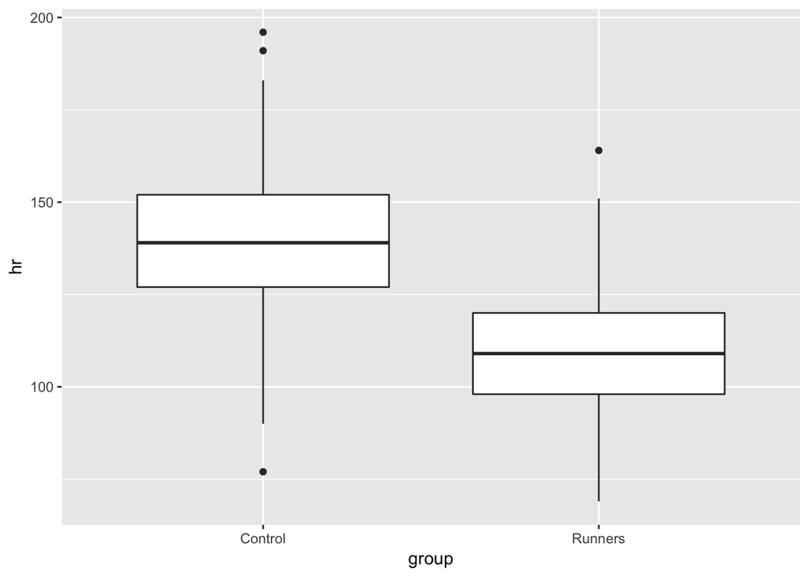

```r
ggplot(z, aes(x=group, y=hr)) + geom_boxplot()
```

```r
m2 <- lm(hr ~ group + gender, data=z)
summary(m2)
```

```
##
## Call:
## lm(formula = hr ~ group + gender, data = z)
##
## Residuals:
##     Min      1Q  Median      3Q     Max
## -54.497  -9.499  -0.490  10.502  49.498
##
## Coefficients:
##              Estimate Std. Error t value Pr(>|t|)
## (Intercept)  146.5025     0.9567  153.13   <2e-16 ***
## groupRunners -29.0200     1.1047  -26.27   <2e-16 ***
## genderMale   -15.0050     1.1047  -13.58   <2e-16 ***
## ---
## Signif. codes:  0 '***' 0.001 '**' 0.01 '*' 0.05 '.' 0.1 ' ' 1
##
## Residual standard error: 15.62 on 797 degrees of freedom
## Multiple R-squared:  0.5232, Adjusted R-squared:  0.522
## F-statistic: 437.3 on 2 and 797 DF,  p-value: < 2.2e-16
```

```r
anova(m2)
```

```
## Analysis of Variance Table
##
## Response: hr
##            Df Sum Sq Mean Sq F value    Pr(>F)
## group       1 168432  168432   690.1 < 2.2e-16 ***
## gender      1  45030   45030   184.5 < 2.2e-16 ***
## Residuals 797 194524     244
## ---
## Signif. codes:  0 '***' 0.001 '**' 0.01 '*' 0.05 '.' 0.1 ' ' 1
```

```r
m3 <- lm(hr ~ group * gender, data=z)
summary(m3)
```

```
##
## Call:
## lm(formula = hr ~ group * gender, data = z)
##
## Residuals:
##     Min      1Q  Median      3Q     Max
## -53.000  -9.985  -0.975  10.025  48.015
##
## Coefficients:
##                         Estimate Std. Error t value Pr(>|t|)
## (Intercept)              148.000      1.100 134.511  < 2e-16 ***
## groupRunners             -32.015      1.556 -20.575  < 2e-16 ***
## genderMale               -18.000      1.556 -11.568  < 2e-16 ***
## groupRunners:genderMale    5.990      2.201   2.722  0.00663 **
## ---
## Signif. codes:  0 '***' 0.001 '**' 0.01 '*' 0.05 '.' 0.1 ' ' 1
##
## Residual standard error: 15.56 on 796 degrees of freedom
## Multiple R-squared:  0.5276, Adjusted R-squared:  0.5258
## F-statistic: 296.3 on 3 and 796 DF,  p-value: < 2.2e-16
```

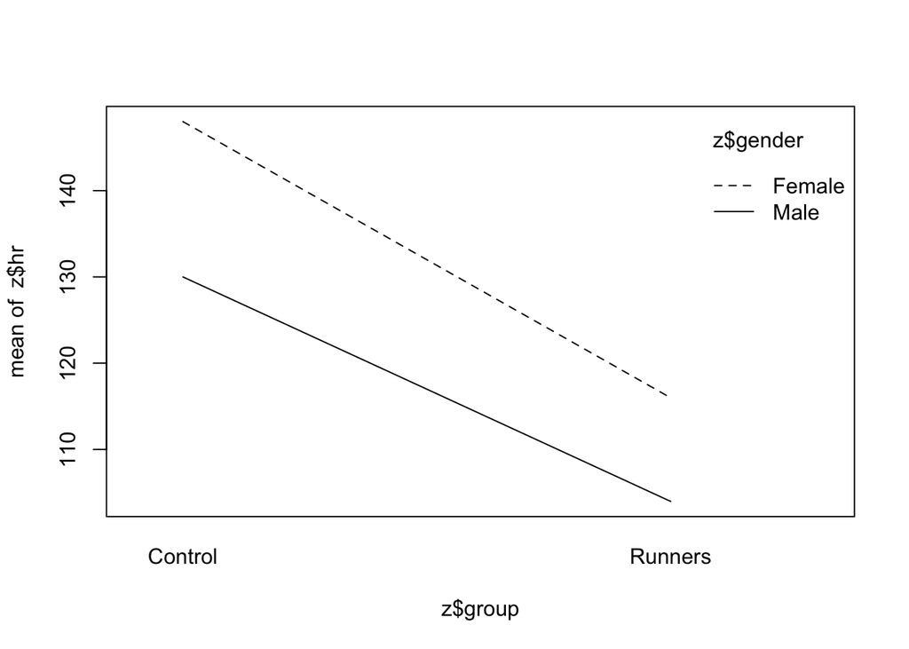

```r
interaction.plot(z$group, z$gender, z$hr)
```